#Name: Sweta Kumari #STATISTICS OF ONE AND TWO SAMPLES

#Central tendency #1. Mode #Let’s define x

```r
x<-(1:9)
rm(x)
```

#Read mode.txt from the directory.

```r
distribution<-read.table("C:\\Users\\Sweta\\Documents\\Data\\mode.txt", header=T)
attach(distribution)
names(distribution)
```

```
## [1] "fx" "fy" "fz" "x"
```

#Draw 2 histograms side by side: Mode gives idea about the central tendency of the data set.

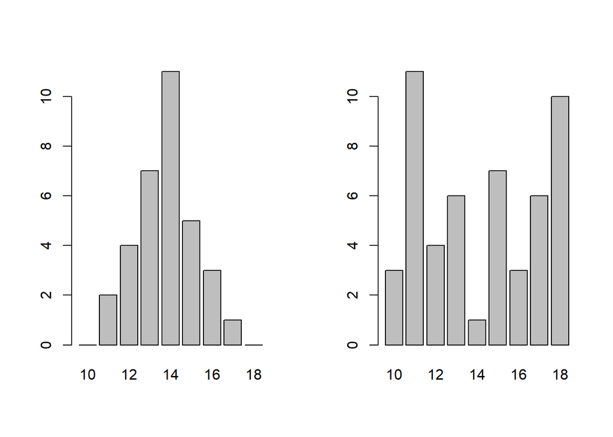

```r
par(mfrow=c(1,2))
barplot(fx,names=as.character(x))
barplot(fy,names=as.character(x))
```

#2.Median: Another way of measuring central tendency is Median.Define y vector where it has all elements of x values.

```r
y<-rep(x,fx)
y
```

```
##  [1] 11 11 12 12 12 12 13 13 13 13 13 13 13 14 14 14 14 14 14 14 14 14 14 14 15
## [26] 15 15 15 15 16 16 16 17
```

#Sort the value of Y. #Determine how many y values we have in y vector.

```r
sort(y)
```

```
##  [1] 11 11 12 12 12 12 13 13 13 13 13 13 13 14 14 14 14 14 14 14 14 14 14 14 15
## [26] 15 15 15 15 16 16 16 17
```

```r
length(y)
```

```
## [1] 33
```

#Since length is odd, we can find median by determining 17th value of y.

```r
ceiling(length(y)/2)
```

```
## [1] 17
```

#Find the value of the y in 17th position

```r
y[17]
```

```
## [1] 14
```

#Or, we can determine y value at 17th position:

```r
y[ceiling(length(y)/2)]
```

```
## [1] 14
```

#We can find the median with built-in function also:

```r
median(y)
```

```
## [1] 14
```

#3. Arithmetic mean:We can calculate this by sum and length function

```r
sum(y)/length(y)
```

```
## [1] 13.78788
```

#or use built-in function

```r
mean(y)
```

```
## [1] 13.78788
```

#4. Geometric Mean:

```r
prod(y)^(1/length(y))
```

```
## [1] 13.71531
```

#another way of finding the Geometric mean is find the mean of log y and then take antilog. Here log has base e.

```r
meanlogy<-sum(log(y))/length(y)
meanlogy
```

```
## [1] 2.618513
```

```r
exp(meanlogy)
```

```
## [1] 13.71531
```

#There is no built-in function for geometric mean but we can write as follows:

```r
geometric<-function(x) exp(sum(log(x))/length(x))
geometric(y)
```

```
## [1] 13.71531
```

#Geometric mean is useful in extreme data set. Foe instance, consider aphids count in plants:

```r
aphids<-c(10,1,1,10,1000)
```

#We can find Arithmetic mean but it will not give measure of central tendency

```r
mean(aphids)
```

```
## [1] 204.4
```

#Geometric mean can be found to know more about the central tendency of the data

```r
geometric(aphids)
```

```
## [1] 10
```

#5. Harmonic Mean:Let’s find mean of the all 4 velocities

```r
mean(c(1,2,4,1))
```

```
## [1] 2
```

#To find the Harmonic mean:

```r
4/sum(1/c(1,2,4,1))
```

```
## [1] 1.454545
```

#Let’s write harmonic mean formula:

```r
harmonic<-function(x) 1/mean(1/x)
harmonic(y)
```

```
## [1] 13.64209
```

#mode(y) will not give mode of the dataset. It suggests the type of the y (numeric).

```r
mode(y)
```

```
## [1] "numeric"
```

#Frequnecy distribution of fz:

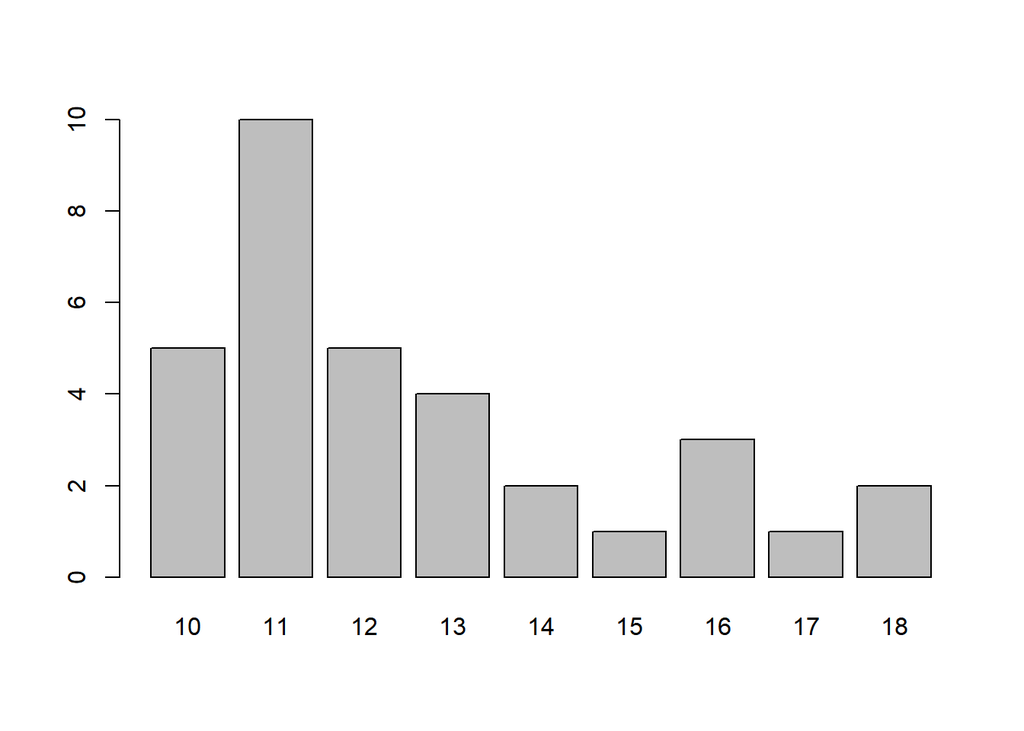

```r
par(mfrow=c(1,1))
barplot(fz,names=as.character(x))
```

#Define w and find all information for central tendency:Here largets mode is at x=11.

```r
w<-rep(x,fz)
mean(w)
```

```
## [1] 12.60606
```

```r
median(w)
```

```
## [1] 12
```

```r
geometric(w)
```

```
## [1] 12.4038
```

```r
harmonic(w)
```

```
## [1] 12.22037
```

#6. Measuring variation: Define y as follows and plot the graph:

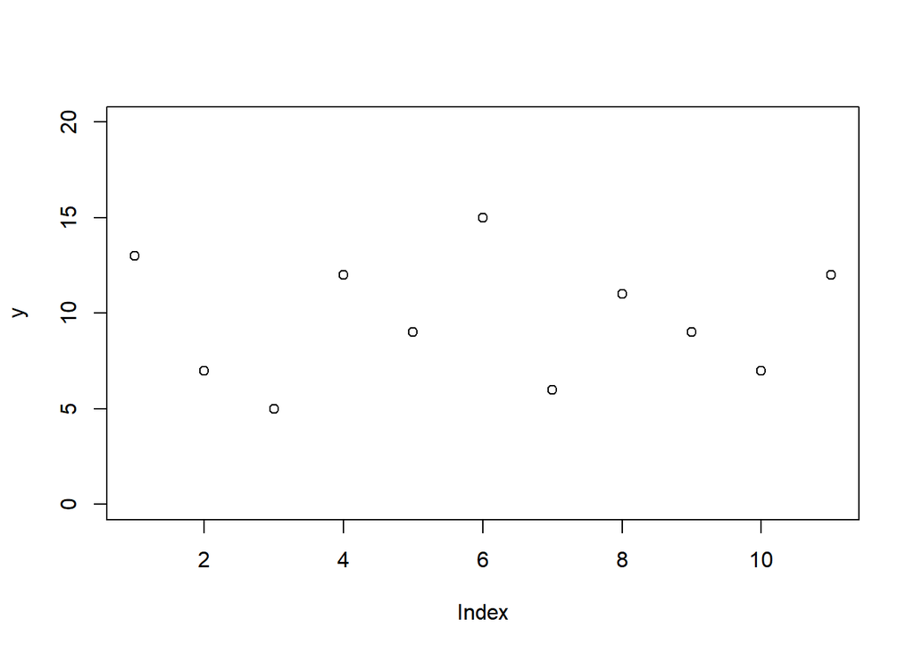

```r
y<-c(13,7,5,12,9,15,6,11,9,7,12)
plot(y,ylim=c(0,20))
```

#To find the variability of the y, find range of y:

```r
range(y)
```

```
## [1]  5 15
```

#To plot the line with average value of y and zero slope :

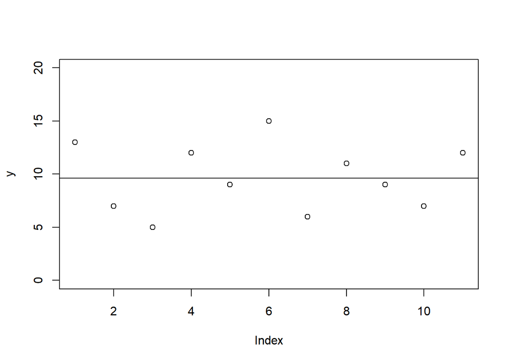

```r
y<-c(13,7,5,12,9,15,6,11,9,7,12)
plot(y,ylim=c(0,20))
abline(mean(y),0)
```

#7. Find the variance: Define A,B,C and find mean for all vectors

```r
A<-c(3,4,4,3,2,3,1,3,5,2)
B<-c(5,5,6,7,4,4,3,5,6,5)
C<-c(3,3,2,1,10,4,3,11,3,10)
mean(A)
```

```
## [1] 3
```

```r
mean(B)
```

```
## [1] 5
```

```r
mean(C)
```

```
## [1] 5
```

#Find the differences y- ybar and then find the sum of suquares

```r
dA<-A-3
dB<-B-5
dC<-C-5
SSA<-sum(dA^2)
SSB<-sum(dB^2)
SSC<-sum(dC^2)
```

#Find the variance by dividing sum of squares by degree of freedom

```r
s2A<-SSA/9
s2B<-SSB/9
s2C<-SSC/9
s2A;s2B;s2C
```

```
## [1] 1.333333
```

```
## [1] 1.333333
```

```
## [1] 14.22222
```

#Bulit-in function to find variance

```r
s2A<-var(A)
s2A
```

```
## [1] 1.333333
```

#To know if variance of garden c is significantly higher than other variance. #Variance of garden C is significantly higher as it is more than 4 times the variance of other garden.

```r
14.2222 / 1.3333
```

```
## [1] 10.66692
```

#Standard error of market gardens A, B, C

```r
sqrt(s2A/10)
```

```
## [1] 0.3651484
```

```r
sqrt(s2B/10)
```

```
## [1] 0.3651484
```

```r
sqrt(s2C/10)
```

```
## [1] 1.19257
```

#8. Find the t value and confidence interval: #Find t value at 95% Confidence interval for two tail test; t-value at left tail:

```r
qt(.025,9)
```

```
## [1] -2.262157
```

#Find the t value for right tail:

```r
qt(.975,9)
```

```
## [1] 2.262157
```

#Find t value at 99% Confidence interval for two tail test

```r
qt(.995,9)
```

```
## [1] 3.249836
```

#Find t value at 99.5% Confidence interval for two tail test

```r
qt(.9975,9)
```

```
## [1] 3.689662
```

#Confidence interval for garden B

```r
qt(.975,9)*sqrt(1.33333/10)
```

```
## [1] 0.826022
```

#9. Quantiles:Consider z with 1000 random numbers from standard normal distribution where mean is 0 and standard deviation is 1.

```r
z<-rnorm(1000)
```

#calculate mean

```r
mean(z)
```

```
## [1] 0.03061425
```

#calculate quantiles

```r
quantile(z,c(.025,.975))
```

```
##      2.5%     97.5%
## -1.961367  2.075471
```

#consider z with 10000 random numbers from standard normal distribution and find quantiles.

```r
z<-rnorm(10000)
quantile(z,c(.025,.975))
```

```
##     2.5%    97.5%
## -2.01030  1.99265
```

#10. Robust estimators:Define y as follows

```r
y<-c(3,4,6,4,5,2,4,5,1,5,4,6)
```

#Find the Median Absolute Deviation

```r
mad(y)
```

```
## [1] 1.4826
```

#Find the standard deviation

```r
sd(y)
```

```
## [1] 1.505042
```

#Define new vector y1 by adding 100 as outleir in the existing vector y

```r
y1<-c(y,100)
```

#find the mean of y1

```r
mean(y1)
```

```
## [1] 11.46154
```

#find the standard deviation of y1

```r
sqrt(var(y1))
```

```
## [1] 26.64149
```

#Find the Median Absolute Deviation of y1

```r
mad(y1)
```

```
## [1] 1.4826
```

#Create function outlier:If standard deviation is greater than 4 times Median Absolute Deviation then it is outlier.

```r
outlier<-function(x) {
  if(sqrt(var(x))>4*mad(x))   print("Outliers present")
  else   print("Deviation reasonable")}
```

```r
#Check for vector y
outlier(y)
```

```
## [1] "Deviation reasonable"
```

```r
#Check for vector y1
outlier(y1)
```

```
## [1] "Outliers present"
```

#11. Single sample estimation: #Read the light file

```r
light<-read.table("C:\\Users\\Sweta\\Documents\\Data\\light.txt",header=T)
attach(light)
names(light)
```

```
## [1] "speed"
```

#Plot histogram for speed

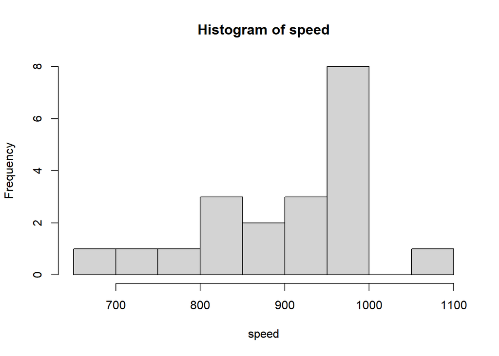

```r
hist(speed)
```

#summary of speed

```r
summary(speed)
```

```
##    Min. 1st Qu.  Median    Mean 3rd Qu.    Max.
##     650     850     940     909     980    1070
```

#12. Inference in 1-sample case: #Conduct Wilcoxon’s signed rank test for speed of light.

```r
library(stats)
wilcox.test(speed,mu=990)
```

```
##
##  Wilcoxon signed rank test with continuity correction
##
## data:  speed
## V = 22.5, p-value = 0.00213
## alternative hypothesis: true location is not equal to 990
```

#Conduct student’s t-test.

```r
t.test(speed,mu=990)
```

```
##
##  One Sample t-test
##
## data:  speed
## t = -3.4524, df = 19, p-value = 0.002669
## alternative hypothesis: true mean is not equal to 990
## 95 percent confidence interval:
##  859.8931 958.1069
## sample estimates:
## mean of x
##       909
```

#13. Comparing two means: find the critical value of student’s t

```r
qt(.975,18)
```

```
## [1] 2.100922
```

#Value of t-statistics

```r
(mean(A)-mean(B))/sqrt(s2A/10+s2B/10)
```

```
## [1] -3.872983
```

#We can use built-in function to calculate the t-statistics

```r
t.test(A,B)
```

```
##
##  Welch Two Sample t-test
##
## data:  A and B
## t = -3.873, df = 18, p-value = 0.001115
## alternative hypothesis: true difference in means is not equal to 0
## 95 percent confidence interval:
##  -3.0849115 -0.9150885
## sample estimates:
## mean of x mean of y
##         3         5
```

#14. Wilcoxon rank sum test: Plot the histogram for garden B and C to check the non-normality of the error:

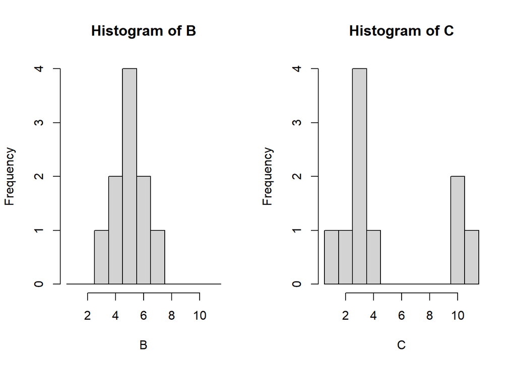

```r
par(mfrow=c(1,2))
hist(B,breaks=c(0.5:11.5))
hist(C,breaks=c(0.5:11.5))
```

#Combine both vectors B and C

```r
combined<-c(B,C)
combined
```

```
##  [1]  5  5  6  7  4  4  3  5  6  5  3  3  2  1 10  4  3 11  3 10
```

#Create a list with sample name B and C

```r
sample<-c(rep("B",10),rep("C",10))
sample
```

```
##  [1] "B" "B" "B" "B" "B" "B" "B" "B" "B" "B" "C" "C" "C" "C" "C" "C" "C" "C" "C"
## [20] "C"
```

#Find the rank of the combined vector

```r
rank.combi<-rank(combined)
rank.combi
```

```
##  [1] 12.5 12.5 15.5 17.0  9.0  9.0  5.0 12.5 15.5 12.5  5.0  5.0  2.0  1.0 18.5
## [16]  9.0  5.0 20.0  5.0 18.5
```

#Calculate the sum of the ranks for garden B.

```r
sum(rank.combi[sample=="B"])
```

```
## [1] 121
```

#Calculate the sum of the ranks for garden C.

```r
sum(rank.combi[sample=="C"])
```

```
## [1] 89
```

#Or,Use tapply function to calculate the sum of the ranks for garden B and C.

```r
tapply(rank.combi,sample,sum)
```

```
##   B   C
## 121  89
```

#Conduct Wilcoxon rank sum test with built-in function

```r
wilcox.test(B,C)
```

```
##
##  Wilcoxon rank sum test with continuity correction
##
## data:  B and C
## W = 66, p-value = 0.2349
## alternative hypothesis: true location shift is not equal to 0
```

#15. Tests on paired samples: Define x and y as follows

```r
x<-c(20,15,10,5,20,15,10,5,20,15,10,5,20,15,10,5)
y<-c(23,16,10,4,22,15,12,7,21,16,11,5,22,14,10,6)
```

#Conduct student’s t-test:

```r
t.test(x,y)
```

```
##
##  Welch Two Sample t-test
##
## data:  x and y
## t = -0.40876, df = 29.755, p-value = 0.6856
## alternative hypothesis: true difference in means is not equal to 0
## 95 percent confidence interval:
##  -5.248256  3.498256
## sample estimates:
## mean of x mean of y
##    12.500    13.375
```

#Conduct student’s paired t-test:

```r
t.test(x,y,paired=T)
```

```
##
##  Paired t-test
##
## data:  x and y
## t = -3.0502, df = 15, p-value = 0.0081
## alternative hypothesis: true difference in means is not equal to 0
## 95 percent confidence interval:
##  -1.4864388 -0.2635612
## sample estimates:
## mean of the differences
##                  -0.875
```

#16. Central Limit Theorem : Define y with 1000 random number of negative binomial random numbers with parameters size as 1, probability as 0.2

```r
par(mfrow=c(1,2))
y<-rnbinom(1000,1,.2)
```

#Calculate the mean of Y

```r
mean(y)
```

```
## [1] 3.934
```

#Calculate the variance of Y

```r
var(y)
```

```
## [1] 18.45009
```

#To get the table for frequnecy distribution

```r
table(y)
```

```
## y
##   0   1   2   3   4   5   6   7   8   9  10  11  12  13  14  15  16  18  19  20
## 195 164 136  86  92  61  58  48  30  28  24  13  13  16   8   9   3   2   6   1
##  21  24  26  34
##   1   3   2   1
```

#Plot histogram with break points.Then plot histogram from the same set of y with sample size as 30

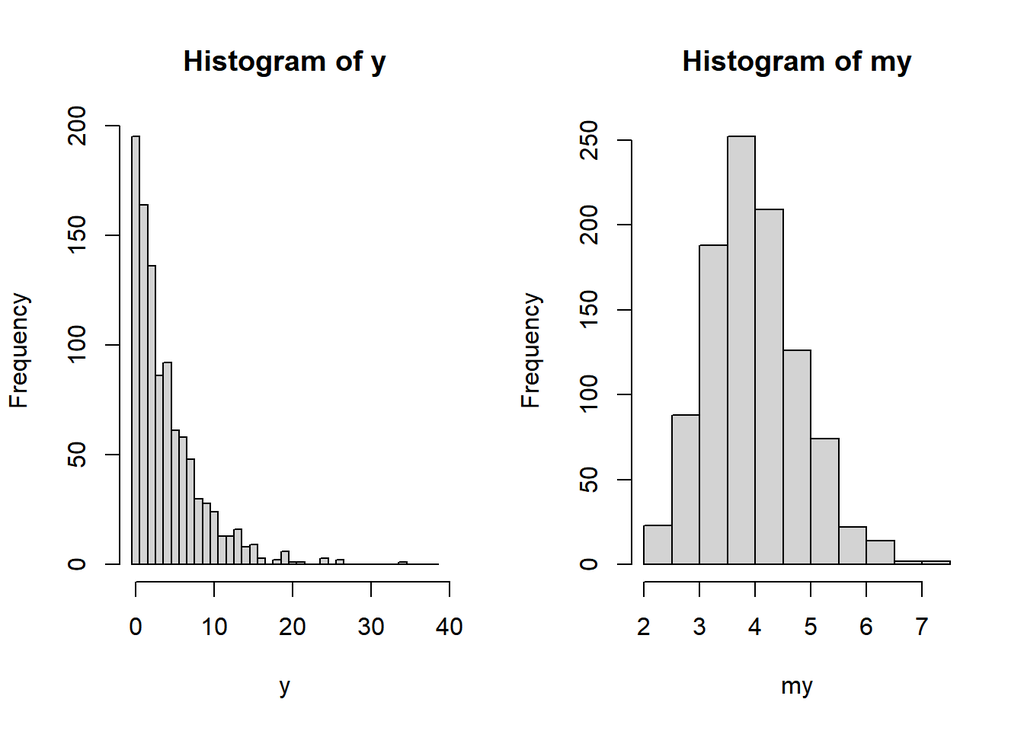

```r
par(mfrow=c(1,2))
hist(y,breaks=-0.5:38.5)
my <- numeric(1000)
for (i in 1:1000) {
  y <- rnbinom(30, 1, 0.2)
  my[i] <- mean(y) }
hist(my)
```

```r
par(mfrow=c(1,1))
```